# DAY 1 LINEAR REGRESSION

Tamas Nagy

2022-07-12

```r
# Sets global chunk options
knitr::opts_chunk$set(echo = TRUE)

# Load these packages
suppressPackageStartupMessages(library(tidyverse))
library(broom)
library(performance)
library(sjPlot)
# Setting the default ggplot2 theme
theme_set(theme_light())
```

```r
# Read the cocktails dataset
cocktails <- read_tsv(here::here("data/cocktail_data.tsv"))
```

# Using the `lm()` formula

Doing a regression in R is super easy. Just use the `lm()` function. The first argument is the formula, thus if you want to pipe something in `lm()` you need to expicitly name the data argument. E.g. data %>% lm(y ~ x, data = .)

The **formula** is symbolic expression that defines a model.

It takes a format like this:

`y ~ 1 + x + z*w - z:w`

The elements of the formula are:  
- `~` : on the left hand side, there is the outcome (y), on the right hand, the predictors.  
- `1` : refers to the intercept that does not have to be written out as it is added by default. If you want to remove the intercept, you have to use 0 instead of 1.  
- `+` : you can add predictors using the + sign.  
- `*` : means to take two (or more) pradictors, and use their main effect AND also their interaction. `z*w` translates into `z + w + z:w`.  
- `:` : referes to an interaction, without the main effects of the predictors.  
- `-` : removes a predictor. For e.g. `z*w - z:w` translates into: `z + w`

```r
lm(abv ~ acid, data = cocktails)
```

```
##
## Call:
## lm(formula = abv ~ acid, data = cocktails)
##
## Coefficients:
## (Intercept)         acid
##       24.77       -10.07
```

This returns just the formula, the estimated intercept and the slope of the model. However a lot is stored in the lm object. To be able to get them, store it in a variable.

```r
acid_lm <- lm(abv ~ acid, data = cocktails)
```

The `summary()` function shows the most important output from the model that are needed for reporting.

```r
summary(acid_lm)
```

```
##
## Call:
## lm(formula = abv ~ acid, data = cocktails)
##
## Residuals:
##     Min      1Q  Median      3Q     Max
## -8.3749 -2.3001  0.7801  2.1304  7.5251
##
## Coefficients:
##             Estimate Std. Error t value Pr(>|t|)
## (Intercept)  24.7749     0.8868  27.937  < 2e-16 ***
## acid        -10.0662     1.4619  -6.886 6.88e-09 ***
## ---
## Signif. codes:  0 '***' 0.001 '**' 0.01 '*' 0.05 '.' 0.1 ' ' 1
##
## Residual standard error: 3.73 on 53 degrees of freedom
## Multiple R-squared:  0.4722, Adjusted R-squared:  0.4622
## F-statistic: 47.42 on 1 and 53 DF,  p-value: 6.885e-09
```

This also works without storing the results. However when you use pipes, mind that in lm(), data is not the first parameter

```r
cocktails %>%
  lm(abv ~ acid, data = .) %>%
  summary()
```

```
##
## Call:
## lm(formula = abv ~ acid, data = .)
##
## Residuals:
##     Min      1Q  Median      3Q     Max
## -8.3749 -2.3001  0.7801  2.1304  7.5251
##
## Coefficients:
##             Estimate Std. Error t value Pr(>|t|)
## (Intercept)  24.7749     0.8868  27.937  < 2e-16 ***
## acid        -10.0662     1.4619  -6.886 6.88e-09 ***
## ---
## Signif. codes:  0 '***' 0.001 '**' 0.01 '*' 0.05 '.' 0.1 ' ' 1
##
## Residual standard error: 3.73 on 53 degrees of freedom
## Multiple R-squared:  0.4722, Adjusted R-squared:  0.4622
## F-statistic: 47.42 on 1 and 53 DF,  p-value: 6.885e-09
```

## Plotting a linear model

Plot the linear regression using the bulit in modeling of ggplot2

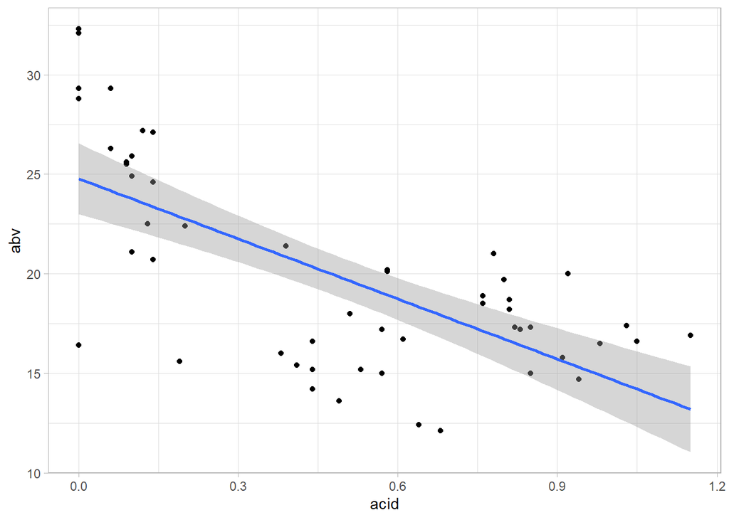

```r
cocktails %>%
  ggplot() +
  aes(y = abv, x = acid) +
  geom_point() +
  geom_smooth(method = "lm")
```

The lm object is a large list, with lots of special information that we only need occasionally.

## Getting clean results

To get clean results, use the `{broom}` package. The `{broom}` package creates tidy tibbles from the most important information of statistical result objects. It works for most regression types and other statistical outputs. The `{broom}` package has three important functions.

- `tidy()` returns the model summary about the parameters in a neat data frame.

```r
tidy(acid_lm)
```

```
## # A tibble: 2 × 5
##   term        estimate std.error statistic  p.value
##   <chr>          <dbl>     <dbl>     <dbl>    <dbl>
## 1 (Intercept)     24.8     0.887     27.9  2.19e-33
## 2 acid           -10.1     1.46      -6.89 6.88e- 9
```

- `glance()` returns important model performance metrics.

```r
glance(acid_lm)
```

```
## # A tibble: 1 × 12
##   r.squared adj.r.squared sigma statistic       p.value    df logLik   AIC   BIC
##       <dbl>         <dbl> <dbl>     <dbl>         <dbl> <dbl>  <dbl> <dbl> <dbl>
## 1     0.472         0.462  3.73      47.4 0.00000000688     1  -149.  305.  311.
## # … with 3 more variables: deviance <dbl>, df.residual <int>, nobs <int>
```

- `augment()` adds important new columns to your data frames, such as the residuals (.resid), and predicted values corresponding your independent variables. These can be useful for residual diagnostics, and plotting model predictions.í

```r
augment(acid_lm)
```

```
## # A tibble: 55 × 8
##      abv  acid .fitted .resid   .hat .sigma  .cooksd .std.resid
##    <dbl> <dbl>   <dbl>  <dbl>  <dbl>  <dbl>    <dbl>      <dbl>
##  1  12.1  0.68    17.9 -5.83  0.0232   3.68 0.0297       -1.58
##  2  12.4  0.64    18.3 -5.93  0.0212   3.67 0.0280       -1.61
##  3  13.6  0.49    19.8 -6.24  0.0182   3.66 0.0264       -1.69
##  4  15.2  0.53    19.4 -4.24  0.0183   3.72 0.0123       -1.15
##  5  14.7  0.94    15.3 -0.613 0.0480   3.76 0.000714     -0.168
##  6  15    0.85    16.2 -1.22  0.0370   3.76 0.00213      -0.333
##  7  15    0.85    16.2 -1.22  0.0370   3.76 0.00213      -0.333
##  8  15.6  0.19    22.9 -7.26  0.0329   3.62 0.0667       -1.98
##  9  16.4  0       24.8 -8.37  0.0565   3.57 0.160        -2.31
## 10  16.5  0.98    14.9  1.59  0.0536   3.76 0.00544       0.438
## # … with 45 more rows
```

## Getting standardized coefficients

To get the standardized coefficients (scale free), you need to standardize the output and predictor variables. Use the `scale()` function on all variables in the model.

```r
acid_lm_std <- lm(scale(abv) ~ scale(acid), data = cocktails)
summary(acid_lm_std)
```

```
##
## Call:
## lm(formula = scale(abv) ~ scale(acid), data = cocktails)
##
## Residuals:
##     Min      1Q  Median      3Q     Max
## -1.6466 -0.4522  0.1534  0.4189  1.4795
##
## Coefficients:
##               Estimate Std. Error t value Pr(>|t|)
## (Intercept) -1.121e-17  9.888e-02   0.000        1
## scale(acid) -6.872e-01  9.979e-02  -6.886 6.88e-09 ***
## ---
## Signif. codes:  0 '***' 0.001 '**' 0.01 '*' 0.05 '.' 0.1 ' ' 1
##
## Residual standard error: 0.7333 on 53 degrees of freedom
## Multiple R-squared:  0.4722, Adjusted R-squared:  0.4622
## F-statistic: 47.42 on 1 and 53 DF,  p-value: 6.885e-09
```

You can check that the slope of acid now matches the correlation between abv and acid. Mind that correlation and linear regression finds the same slope in a different way!

```r
cor(cocktails$abv, cocktails$acid)
```

```
## [1] -0.6871614
```

## Predicting values based on the model

Create predictions with new data. `predict()` returns a vector of predictions

```r
newdata <- tibble(acid = c(0.2, 0.3, 0.4))
predict(acid_lm, newdata)
```

```
##        1        2        3
## 22.76166 21.75504 20.74842
```

## Updating the model

Add more predictors using the `update()` function! You don’t need to write out all things in your formula. By using the `.` you can tell the function to leave everything as it was. All other parts of the formula work the same way. Note: your original data is also kept in the lm object, so you don’t even need to define that!

```r
new_mod <- update(acid_lm, . ~ . + sugar)
```

# Checking the assumptions for linear regression

There are multiple ways to plot and investigate model assumptions in R I prefer to use solutions that make everything in one go. To explore the residuals, the `{performance}` package makes diagnostic plots, using the `check_model()` function.

```r
library(performance)
```

*Sidenote: the `{performance}` package is part of the `{easystats}` package family, that is geared towards making the reporting of statistics more seamless and standardized. It can save a lot of time to use these packages! To install `{easystats}`, use the following line. Mind that easystats is not from CRAN!*

```r
# install.packages("easystats", repos = "https://easystats.r-universe.dev")
# easystats::install_suggested() # This will take a lot of time!!
```

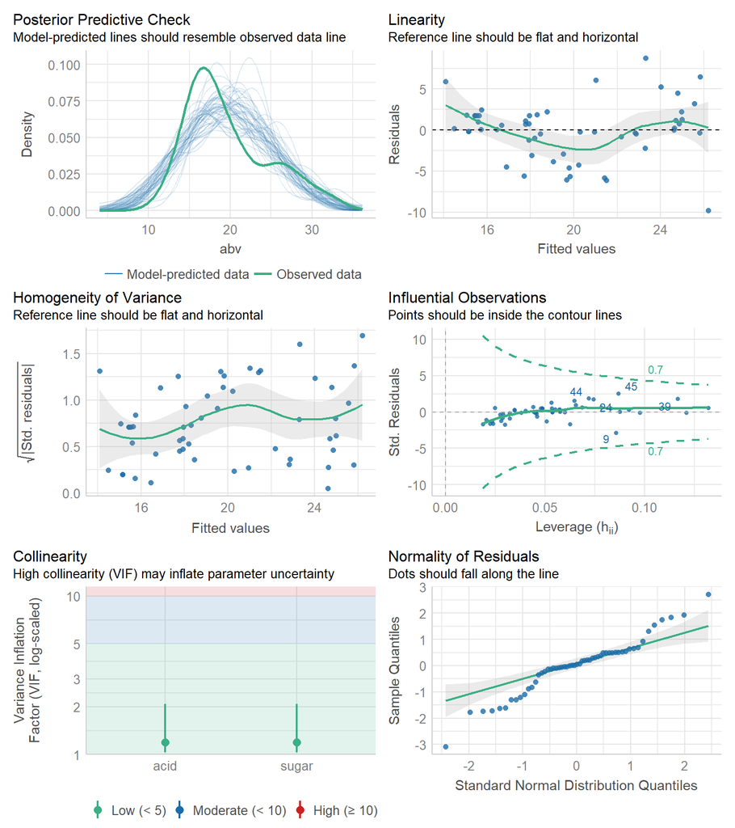

```r
check_model(new_mod)
```

To check heteroscetasticity inspect the residual diagnostic plots. Multicollinearity is also displayed if you have more than one predictor in your model. Measure multicollinearity using the variance inflation factor (VIF) Values for any variable should not be larger than 5.

```r
car::vif(new_mod)
```

```
##     acid    sugar
## 1.189188 1.189188
```

Measuring the independence of residuals

```r
car::dwt(new_mod)
```

```
##  lag Autocorrelation D-W Statistic p-value
##    1       0.5788797     0.7949038       0
##  Alternative hypothesis: rho != 0
```

The homoscedasticity assumption can also be checked using the Bausch-Pagan test from the `{lmtest}` package.

```r
lmtest::bptest(new_mod)
```

```
##
##  studentized Breusch-Pagan test
##
## data:  new_mod
## BP = 8.9094, df = 2, p-value = 0.01162
```

It seems like model has some significant autocorrelation, so the residuals are not independent.

You can also pull out the residuals from the model and check the normality of residuals by running a normality test.

```r
augment(new_mod) %>%
  pull(.resid) %>%
  shapiro.test()
```

```
##
##  Shapiro-Wilk normality test
##
## data:  .
## W = 0.9589, p-value = 0.05761
```

The Shapiro-Wilks test shows that the residuals are normally distributed.

Let’s store the diagnostic values in a variable

```r
acid_lm_diag <- augment(new_mod)
```

# Using multiple predictions

Let’s create multiple models with several predictors

```r
lm1 <- lm(abv ~ acid + sugar, data = cocktails)
lm2 <- lm(abv ~ acid * sugar, data = cocktails)
lm3 <- lm(abv ~ acid : sugar, data = cocktails)
```

Get the confidence intervals for parameters

```r
confint(lm1, level = 0.95)
```

```
##                  2.5 %      97.5 %
## (Intercept)  24.808340 31.58177401
## acid        -11.704627 -5.56263978
## sugar        -1.191674 -0.09313754
```

Preferably, you can also get the confidence intervals using `broom::tidy()`

```r
tidy(lm1, conf.int = TRUE, conf.level = .95)
```

```
## # A tibble: 3 × 7
##   term        estimate std.error statistic  p.value conf.low conf.high
##   <chr>          <dbl>     <dbl>     <dbl>    <dbl>    <dbl>     <dbl>
## 1 (Intercept)   28.2       1.69      16.7  1.50e-22    24.8    31.6
## 2 acid          -8.63      1.53      -5.64 7.05e- 7   -11.7    -5.56
## 3 sugar         -0.642     0.274     -2.35 2.28e- 2    -1.19   -0.0931
```

# Using categorical predictors

R can also deal with categorical variables, as they are automatically dummied, and the first level is taken as baseline.

```r
lm_cat <- lm(abv ~ type, data = cocktails)
```

## Changing the baseline

To change the baseline, you need to convert the character type variable to factor and change the factor levels to set the baseline. E.g. change it to carbonated. I recommend using the tidyverse `fct_relevel()` function from the `{forcats}` package (it is automatically loaded when you load tidyverse).

```r
lm4 <-
  cocktails %>%
  mutate(type = fct_relevel(type, "carbonated")) %>%
  lm(abv ~ acid : sugar + type, data = .)
```

Let’s check the model

```r
tidy(lm4)
```

```
## # A tibble: 7 × 5
##   term         estimate std.error statistic  p.value
##   <chr>           <dbl>     <dbl>     <dbl>    <dbl>
## 1 (Intercept)    17.2       1.11     15.4   3.42e-20
## 2 typeblended     0.583     1.55      0.377 7.08e- 1
## 3 typebuilt      14.9       2.50      5.98  2.64e- 7
## 4 typeeggwhite   -2.45      1.40     -1.75  8.68e- 2
## 5 typeshaken      2.23      0.987     2.26  2.82e- 2
## 6 typestirred     8.85      1.19      7.41  1.76e- 9
## 7 acid:sugar     -0.310     0.184    -1.68  9.88e- 2
```

## Post-hoc analysis

We can calculate the marginal means, and check if the difference between the categorical levels is significant. The `estimate_contrasts()` function from the `{modelbased}` package can be used for both post-hoc tests and planned contrasts. For the 6 levels, we have to do `(6*5/2)` = 15 pairwise tests. The p value has to be adjusted for multiple comparisons (FDR correction).

```r
library(modelbased)
# Function name a bit misleading, you get post-hoc tests!
estimate_contrasts(lm4, contrast = "type", adjust = "fdr")
```

```
## Marginal Contrasts Analysis
##
## Level1     |   Level2 | Difference |          95% CI |   SE | t(48) |      p
## ----------------------------------------------------------------------------
## blended    |    built |     -14.37 | [-22.76, -5.97] | 2.72 | -5.29 | < .001
## blended    | eggwhite |       3.04 | [ -2.24,  8.31] | 1.71 |  1.78 | 0.489
## blended    |   shaken |      -1.65 | [ -5.89,  2.59] | 1.37 | -1.20 | 0.834
## blended    |  stirred |      -8.27 | [-13.20, -3.33] | 1.60 | -5.17 | < .001
## built      | eggwhite |      17.40 | [  9.28, 25.52] | 2.63 |  6.62 | < .001
## built      |   shaken |      12.72 | [  5.08, 20.35] | 2.47 |  5.14 | < .001
## built      |  stirred |       6.10 | [ -1.02, 13.22] | 2.31 |  2.65 | 0.106
## carbonated |  blended |      -0.58 | [ -5.36,  4.20] | 1.55 | -0.38 | 0.999
## carbonated |    built |     -14.95 | [-22.66, -7.23] | 2.50 | -5.98 | < .001
## carbonated | eggwhite |       2.45 | [ -1.88,  6.79] | 1.40 |  1.75 | 0.508
## carbonated |   shaken |      -2.23 | [ -5.28,  0.82] | 0.99 | -2.26 | 0.230
## carbonated |  stirred |      -8.85 | [-12.54, -5.16] | 1.19 | -7.41 | < .001
## eggwhite   |   shaken |      -4.69 | [ -8.44, -0.93] | 1.21 | -3.86 | 0.004
## eggwhite   |  stirred |     -11.30 | [-15.76, -6.84] | 1.44 | -7.83 | < .001
## shaken     |  stirred |      -6.62 | [-10.08, -3.15] | 1.12 | -5.89 | < .001
##
## Marginal contrasts estimated at type
## p-value adjustment method: Benjamini & Hochberg (1995)
```

## Using contrasts

There are different types of contrasts to be set. Treatment contrast is the default, it is comparing the base level to the others. If we use this, the model intercept will be equal to the mean of the baseline category.

Treatment contrast matrix

```r
contr.treatment(n = 6)
```

```
##   2 3 4 5 6
## 1 0 0 0 0 0
## 2 1 0 0 0 0
## 3 0 1 0 0 0
## 4 0 0 1 0 0
## 5 0 0 0 1 0
## 6 0 0 0 0 1
```

```r
lm_cat <- lm(abv ~ type, data = cocktails,
             contrasts = list(type = contr.treatment(n = 6, base = 1)))

summary(lm_cat)
```

```
##
## Call:
## lm(formula = abv ~ type, data = cocktails, contrasts = list(type = contr.treatment(n = 6,
##     base = 1)))
##
## Residuals:
##     Min      1Q  Median      3Q     Max
## -5.1438 -1.2021 -0.2437  1.1885  6.4562
##
## Coefficients:
##             Estimate Std. Error t value Pr(>|t|)
## (Intercept)  16.3000     1.3144  12.401  < 2e-16 ***
## type2        15.8000     2.6289   6.010 2.26e-07 ***
## type3        -0.3714     1.5711  -0.236   0.8141
## type4        -2.9750     1.7388  -1.711   0.0934 .
## type5         1.4792     1.3942   1.061   0.2939
## type6         9.5438     1.4324   6.663 2.21e-08 ***
## ---
## Signif. codes:  0 '***' 0.001 '**' 0.01 '*' 0.05 '.' 0.1 ' ' 1
##
## Residual standard error: 2.277 on 49 degrees of freedom
## Multiple R-squared:  0.8182, Adjusted R-squared:  0.7996
## F-statistic:  44.1 on 5 and 49 DF,  p-value: < 2.2e-16
```

In situations where no clear baseline category can be established, it may make more sense to compare each group to the mean of the other groups. This is where Helmert contrasts, generated by the `contr.helmert()` function, can be useful. The idea behind Helmert contrasts is to compare each group to the mean of the “previous” ones. That is, the first contrast represents the difference between group 2 and group 1, the second contrast represents the difference between group 3 and the mean of groups 1 and 2, and so on. One useful thing about Helmert contrasts is that every contrast sums to zero (i.e., all the columns sum to zero). This has the consequence that, the intercept term corresponds to the grand mean.

Helmert contrast matrix

```r
contr.helmert(n = 6)
```

```
##   [,1] [,2] [,3] [,4] [,5]
## 1   -1   -1   -1   -1   -1
## 2    1   -1   -1   -1   -1
## 3    0    2   -1   -1   -1
## 4    0    0    3   -1   -1
## 5    0    0    0    4   -1
## 6    0    0    0    0    5
```

```r
lm_cat <- lm(abv ~ type, data = cocktails,
             contrasts = list(type = contr.helmert(n = 6)))

summary(lm_cat)
```

```
##
## Call:
## lm(formula = abv ~ type, data = cocktails, contrasts = list(type = contr.helmert(n = 6)))
##
## Residuals:
##     Min      1Q  Median      3Q     Max
## -5.1438 -1.2021 -0.2437  1.1885  6.4562
##
## Coefficients:
##             Estimate Std. Error t value Pr(>|t|)
## (Intercept)  20.2127     0.5134  39.374  < 2e-16 ***
## type1         7.9000     1.3144   6.010 2.26e-07 ***
## type2        -2.7571     0.5237  -5.265 3.10e-06 ***
## type3        -2.0295     0.3662  -5.542 1.18e-06 ***
## type4        -0.3268     0.1761  -1.856   0.0695 .
## type5         1.1262     0.1385   8.132 1.20e-10 ***
## ---
## Signif. codes:  0 '***' 0.001 '**' 0.01 '*' 0.05 '.' 0.1 ' ' 1
##
## Residual standard error: 2.277 on 49 degrees of freedom
## Multiple R-squared:  0.8182, Adjusted R-squared:  0.7996
## F-statistic:  44.1 on 5 and 49 DF,  p-value: < 2.2e-16
```

Sum to zero contrast matrix

```r
contr.sum(n = 6)
```

```
##   [,1] [,2] [,3] [,4] [,5]
## 1    1    0    0    0    0
## 2    0    1    0    0    0
## 3    0    0    1    0    0
## 4    0    0    0    1    0
## 5    0    0    0    0    1
## 6   -1   -1   -1   -1   -1
```

```r
lm_cat <- lm(abv ~ type, data = cocktails,
             contrasts = list(type = contr.sum(n = 6)))

summary(lm_cat)
```

```
##
## Call:
## lm(formula = abv ~ type, data = cocktails, contrasts = list(type = contr.sum(n = 6)))
##
## Residuals:
##     Min      1Q  Median      3Q     Max
## -5.1438 -1.2021 -0.2437  1.1885  6.4562
##
## Coefficients:
##             Estimate Std. Error t value Pr(>|t|)
## (Intercept)  20.2127     0.5134  39.374  < 2e-16 ***
## type1        -3.9127     1.1897  -3.289 0.001867 **
## type2        11.8873     1.9285   6.164 1.31e-07 ***
## type3        -4.2842     0.8702  -4.923 1.01e-05 ***
## type4        -6.8877     1.0618  -6.487 4.14e-08 ***
## type5        -2.4336     0.6384  -3.812 0.000386 ***
## ---
## Signif. codes:  0 '***' 0.001 '**' 0.01 '*' 0.05 '.' 0.1 ' ' 1
##
## Residual standard error: 2.277 on 49 degrees of freedom
## Multiple R-squared:  0.8182, Adjusted R-squared:  0.7996
## F-statistic:  44.1 on 5 and 49 DF,  p-value: < 2.2e-16
```

We can also customize the contrast matrix, and create aggregated categories. For example, in the following code, we make a custom matrix that aggregates category 5 with 1:4, and compares it to category 6.

```r
contrast_sum <- contr.sum(n = 6)
contrast_sum[6, ] <- -2
contrast_sum[5, ] <- 1
contrast_sum <- contrast_sum[,-5]

contrast_sum
```

```
##   [,1] [,2] [,3] [,4]
## 1    1    0    0    0
## 2    0    1    0    0
## 3    0    0    1    0
## 4    0    0    0    1
## 5    1    1    1    1
## 6   -2   -2   -2   -2
```

```r
lm_cat <- lm(abv ~ type, data = cocktails,
             contrasts = list(type = contrast_sum))

summary(lm_cat)
```

```
##
## Call:
## lm(formula = abv ~ type, data = cocktails, contrasts = list(type = contrast_sum))
##
## Residuals:
##     Min      1Q  Median      3Q     Max
## -5.0996 -1.1462 -0.2909  1.2547  6.5004
##
## Coefficients:
##             Estimate Std. Error t value Pr(>|t|)
## (Intercept)  20.3938     0.3230  63.145  < 2e-16 ***
## type1        -3.8585     1.1743  -3.286  0.00186 **
## type2        12.4122     1.5352   8.085 1.23e-10 ***
## type3        -4.3644     0.8454  -5.162 4.23e-06 ***
## type4        -6.8923     1.0533  -6.543 3.11e-08 ***
## ---
## Signif. codes:  0 '***' 0.001 '**' 0.01 '*' 0.05 '.' 0.1 ' ' 1
##
## Residual standard error: 2.259 on 50 degrees of freedom
## Multiple R-squared:  0.8174, Adjusted R-squared:  0.8028
## F-statistic: 55.96 on 4 and 50 DF,  p-value: < 2.2e-16
```

# Model selection

You can compare models if you use the same data and same estimation method (e.g. OLS in the case of regression).  
There are 3 widely-used metrics, all provided in `broom::glance()` All of them have the similar underlying principle.  
You could use R2 or adj. R2 for model comparison, but those are usually not sensitive enough, and/or can be biased.  
It is preferable to use the smallest AIC and BIC value. If there are less than two units of difference between models, then the models can be considered equally good/bad. In this case, the rule of parsimony should be applied, meaning that you should prefer the simpler model, i.e. that has the fewer predictors (model df).

```r
glance(lm4)
```

```
## # A tibble: 1 × 12
##   r.squared adj.r.squared sigma statistic  p.value    df logLik   AIC   BIC
##       <dbl>         <dbl> <dbl>     <dbl>    <dbl> <dbl>  <dbl> <dbl> <dbl>
## 1     0.828         0.807  2.24      38.6 9.74e-17     6  -119.  253.  269.
## # … with 3 more variables: deviance <dbl>, df.residual <int>, nobs <int>
```

You can also compare the logLik of models using the `anova()` function. It returns an F value, which is significant if there is a difference.

```r
anova(lm1, lm3)
```

```
## Analysis of Variance Table
##
## Model 1: abv ~ acid + sugar
## Model 2: abv ~ acid:sugar
##   Res.Df    RSS Df Sum of Sq      F  Pr(>F)
## 1     52 666.69
## 2     53 717.32 -1   -50.628 3.9489 0.05218 .
## ---
## Signif. codes:  0 '***' 0.001 '**' 0.01 '*' 0.05 '.' 0.1 ' ' 1
```

This tells us that the more complicated model is not significantly better, so we should not use it.  
You can have more then 2 models, and the comparison refers to the *PREVIOUS* model (so not the baseline). Pair-wise comparisons are thus preferable.

```r
anova(lm1, lm2, lm3, lm4)
```

```
## Analysis of Variance Table
##
## Model 1: abv ~ acid + sugar
## Model 2: abv ~ acid * sugar
## Model 3: abv ~ acid:sugar
## Model 4: abv ~ acid:sugar + type
##   Res.Df    RSS Df Sum of Sq       F    Pr(>F)
## 1     52 666.69
## 2     51 666.22  1      0.47  0.0939    0.7606
## 3     53 717.32 -2    -51.10  5.1136    0.0097 **
## 4     48 239.82  5    477.50 19.1142 2.031e-10 ***
## ---
## Signif. codes:  0 '***' 0.001 '**' 0.01 '*' 0.05 '.' 0.1 ' ' 1
```

To report the results of regression, you have to use a table, according to APA. To create such a table, the easiest is to use the `{sjPlot}` package, that collects all information from the models (predictors and model summary), and creates a nice table.

To get the table in the console, use the `type = "text"` argument.

```r
library(sjPlot)
tab_model(lm1, lm2, title = "Results")
```

Results

|  | abv |  |  | abv |  |  |
| --- | --- | --- | --- | --- | --- | --- |
| Predictors | Estimates | CI | p | Estimates | CI | p |
| (Intercept) | 28.20 | 24.81 – 31.58 | **<0.001** | 28.55 | 23.50 – 33.59 | **<0.001** |
| acid | -8.63 | -11.70 – -5.56 | **<0.001** | -9.52 | -19.46 – 0.41 | 0.060 |
| sugar | -0.64 | -1.19 – -0.09 | **0.023** | -0.71 | -1.59 – 0.17 | 0.113 |
| acid * sugar |  |  |  | 0.15 | -1.41 – 1.70 | 0.850 |
| Observations | 55 |  |  | 55 |  |  |
| R<sup>2</sup> / R<sup>2</sup> adjusted | 0.523 / 0.504 |  |  | 0.523 / 0.495 |  |  |

You can also have the table in different formats, e.g. html. If you do this, you can save the object and view the results using your web browser. We will later learn a way to include those tables to your manuscripts.

Let’s also add standardized coefficients

```r
results_table_html <-
  tab_model(lm1,lm2,lm3,lm4,
            show.std = TRUE,
            show.est = FALSE
  )

results_table_html
```

|  | abv |  |  | abv |  |  |  | abv |  |  |  | abv |  |  |  |
| --- | --- | --- | --- | --- | --- | --- | --- | --- | --- | --- | --- | --- | --- | --- | --- |
| Predictors | std. Beta | standardized CI | p | std. Beta | standardized CI | p | std. p | std. Beta | standardized CI | p | std. p | std. Beta | standardized CI | p | std. p |
| (Intercept) | 0.00 | -0.19 – 0.19 | **<0.001** | -0.01 | -0.22 – 0.20 | **<0.001** | 0.942 | -0.09 | -0.38 – 0.19 | **<0.001** | 0.522 | -0.74 | -1.09 – -0.40 | **<0.001** | **<0.001** |
| acid | -0.59 | -0.80 – -0.38 | **<0.001** | -0.59 | -0.80 – -0.37 | 0.060 | **<0.001** |  |  |  |  |  |  |  |  |
| sugar | -0.25 | -0.45 – -0.04 | **0.023** | -0.24 | -0.46 – -0.03 | 0.113 | **0.028** |  |  |  |  |  |  |  |  |
| acid * sugar |  |  |  | 0.02 | -0.19 – 0.23 | 0.850 | 0.850 | 0.23 | -0.04 – 0.51 | **<0.001** | 0.088 | 0.05 | -0.08 – 0.18 | 0.099 | 0.457 |
| type [blended] |  |  |  |  |  |  |  |  |  |  |  | 0.06 | -0.57 – 0.68 | 0.708 | 0.855 |
| type [built] |  |  |  |  |  |  |  |  |  |  |  | 3.22 | 2.24 – 4.19 | **<0.001** | **<0.001** |
| type [eggwhite] |  |  |  |  |  |  |  |  |  |  |  | -0.53 | -1.10 – 0.04 | 0.087 | 0.068 |
| type [shaken] |  |  |  |  |  |  |  |  |  |  |  | 0.34 | -0.05 – 0.73 | **0.028** | 0.090 |
| type [stirred] |  |  |  |  |  |  |  |  |  |  |  | 1.90 | 1.47 – 2.33 | **<0.001** | **<0.001** |
| Observations | 55 |  |  | 55 |  |  |  | 55 |  |  |  | 55 |  |  |  |
| R<sup>2</sup> / R<sup>2</sup> adjusted | 0.523 / 0.504 |  |  | 0.523 / 0.495 |  |  |  | 0.487 / 0.477 |  |  |  | 0.828 / 0.807 |  |  |  |

You can also specify the file name in the function, which will write the results in a file.

```r
# tab_model(lm1,lm2,lm3,lm4,
#           show.std = TRUE,
#           show.est = FALSE,
#           file = "cocktail_models.html")
```

Or you can write the results manually into a file.

```r
# write_file(results_table_html, "results_table.html")
```